# Выбор модели для классификации пользователей TripAdvisor. Итерация 2

Alexey Shovkun

Tuesday, May 16, 2015

## Разведка исходных данных

Выделяем обучающую и тестовую выборки. Проверку качества модели в процессе подбора её параметров будем делать с использованием метода перекрестной проверки (cross validation) на обучающей выборке. Тестовая выборка будет использована **только** для оценки качества результирующей модели.

Размеры выборок:

- обучающая: 47 экземпляров.
- проверочная: отсутствует.
- тестовая: 20 экземпляров.

## Малоинформативные параметры

Проанализируем, какие параметры не несут информации (вариация равна 0, все значения одинаковы) или почти не несут информации (вариация близка к 0, большинство значений параметра одинаковы). Мы обязаны исключить их из рассмотрения при построении модели, т.к. в противном случае будут ошибки.

```
##               freqRatio percentUnique zeroVar  nzv
## category10         46.0      4.255319   FALSE TRUE
## category15         45.0      6.382979   FALSE TRUE
## userRating10       46.0      4.255319   FALSE TRUE
## userRating15        0.0      2.127660    TRUE TRUE
## userRating20       44.0      8.510638   FALSE TRUE
## tagVegetarian      46.0      4.255319   FALSE TRUE
## tagFashion         22.5      4.255319   FALSE TRUE
## tagNightLife       46.0      4.255319   FALSE TRUE
## tagTourist         22.5      4.255319   FALSE TRUE
## tagSenior           0.0      2.127660    TRUE TRUE
## tagEco             22.5      4.255319   FALSE TRUE
```

Перечисленные выше параметры не могут быть использованы для обучения модели. При сборе большего количества обучающих примеров, следует рассмотреть пользователей, у которых эти параметры не равны 0.

## Сокращение параметров

Мы обладаем небольшой обучающей выборкой, у которой количество параметров (features) сопоставимо или больше количества экземпляров. Для лучшего обучения некоторых моделей, нам стоит откинуть малоинформативные параметры:

- параметры с малой вариацией (см выше).
- параметры, которые сильно коррелируют между собой.

```
##    user  system elapsed
##   29.15    0.45  417.80
```

```
##
## Genetic Algorithm Feature Selection
##
## 47 samples
## 52 predictors
## 2 classes: '0', '1'
##
## Maximum generations: 50
## Population per generation: 10
## Crossover probability: 0.8
## Mutation probability: 0.1
## Elitism: 0
##
## Internal performance values: Accuracy, Kappa
## Subset selection driven to maximize internal Accuracy
##
## External performance values: Accuracy, Kappa
## Best iteration chose by maximizing external Accuracy
## External resampling method: Cross-Validated (10 fold, repeated 5 times)
##
## During resampling:
##   * the top 5 selected variables (out of a possible 52):
##     category50 (100%), badgeHotelReviewsPercent (82%), reviews5Percent (68%), publicationsCount (64%), badgeRestaurantReviewsCount (62%)
##   * on average, 21.4 variables were selected (min = 4, max = 38)
##
## In the final search using the entire training set:
##    * 26 features selected at iteration 44 including:
##      reviews3Percent, travelStatWorldPercent, badgeHotelReviewsPercent, badgeFirstToReviewPercent, badgeAttractionReviewsCount ...
##    * external performance at this iteration is
##
##    Accuracy       Kappa
##      0.6177      0.2188
```

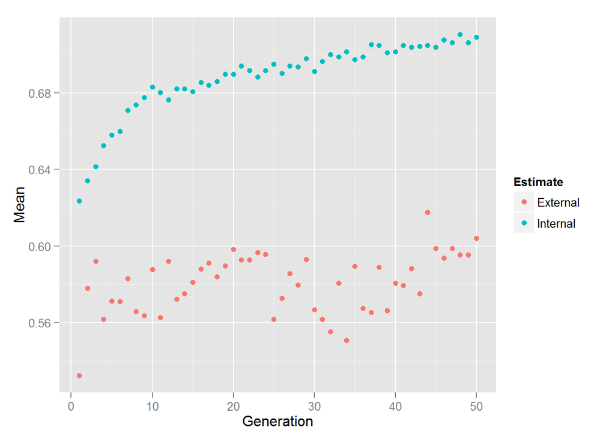

## Обучение модели

Далее будем использовать следующе параметры пользователей:

```
##  [1] "class"                       "sex"
##  [3] "ageGroup"                    "reviews3Percent"
##  [5] "travelStatWorldPercent"      "badgeHotelReviewsPercent"
##  [7] "badgeFirstToReviewPercent"   "badgeAttractionReviewsCount"
##  [9] "badgeFirstToReviewCount"     "publicationsCount"
## [11] "VIPBPYCount"                 "category00"
## [13] "category20"                  "category25"
## [15] "category30"                  "category35"
## [17] "category45"                  "category50"
## [19] "userRating00"                "userRating35"
## [21] "tagGourmet"                  "tagJoinCulture"
## [23] "tagBeach"                    "tagHistory"
## [25] "tagLuxury"                   "tagExtreme"
## [27] "tagArts"                     "tagEconom"
## [29] "tagNone"
```

### LogitBoost Classification Algorithm (Boosted Logistic Regression)

Train logitboost classification algorithm using decision stumps (one node decision trees) as weak learners.

```
## Boosted Logistic Regression
##
## 47 samples
## 28 predictors
##  2 classes: '0', '1'
##
## No pre-processing
## Resampling: Cross-Validated (10 fold)
##
## Summary of sample sizes: 43, 43, 41, 42, 43, 42, ...
##
## Resampling results across tuning parameters:
##
##   nIter  Accuracy   Kappa         Accuracy SD  Kappa SD
##    20    0.5733333   0.007407407  0.3426657    0.6659950
##    30    0.4983333   0.001515152  0.3383374    0.6769354
##    40    0.4650000  -0.044172494  0.2366758    0.4643473
##    45    0.4216667  -0.177505828  0.2314807    0.4753810
##    50    0.4866667   0.005021645  0.3198958    0.6346816
##    53    0.4216667  -0.159190809  0.2671350    0.5334521
##    55    0.4833333  -0.050216450  0.2403701    0.5053471
##    57    0.4783333  -0.041608392  0.2615304    0.5099239
##    60    0.4633333  -0.063916084  0.2706645    0.5089119
##    65    0.5033333  -0.017249417  0.2587720    0.5393090
##    70    0.4850000   0.001501832  0.3186052    0.6372345
##    90    0.5183333   0.062237762  0.3165643    0.6085574
##   100    0.4816667  -0.044172494  0.3308659    0.6616953
##   110    0.4900000   0.005827506  0.3253868    0.6420227
##   150    0.5083333   0.007109557  0.2644876    0.5368998
##   180    0.4883333  -0.026223776  0.2960699    0.5910007
##   200    0.4833333  -0.042890443  0.2211083    0.4504889
##   250    0.4550000  -0.078531469  0.2467130    0.4831393
##   300    0.4583333  -0.086223776  0.2294989    0.4730335
##   400    0.4466667  -0.130536131  0.2128293    0.4310082
##   500    0.5033333  -0.031818182  0.2217773    0.4651650
##
## Accuracy was used to select the optimal model using  the largest value.
## The final value used for the model was nIter = 20.
```

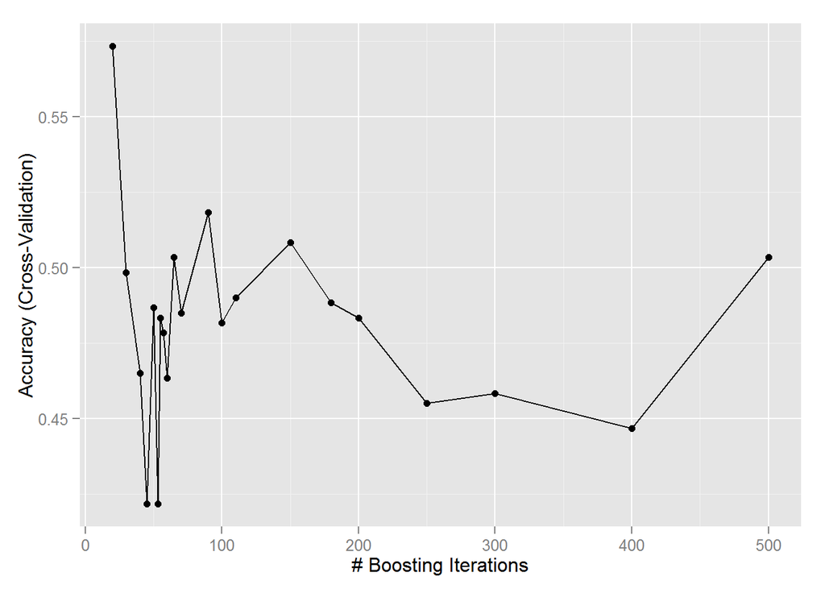

### Дерево решений (Decision Tree)

```
## CART
##
## 47 samples
## 28 predictors
##  2 classes: '0', '1'
##
## No pre-processing
## Resampling: Cross-Validated (10 fold)
##
## Summary of sample sizes: 42, 42, 42, 43, 43, 43, ...
##
## Resampling results across tuning parameters:
##
##   cp          Accuracy  Kappa        Accuracy SD  Kappa SD
##   0.00000000  0.750      0.47191142  0.2173067    0.4469877
##   0.01503759  0.750      0.47191142  0.2173067    0.4469877
##   0.03007519  0.750      0.47191142  0.2173067    0.4469877
##   0.04511278  0.750      0.47191142  0.2173067    0.4469877
##   0.06015038  0.710      0.42905428  0.2766867    0.5129418
##   0.07518797  0.710      0.42905428  0.2766867    0.5129418
##   0.09022556  0.710      0.42905428  0.2766867    0.5129418
##   0.10526316  0.670      0.36953047  0.3198958    0.5772759
##   0.12030075  0.670      0.36953047  0.3198958    0.5772759
##   0.13533835  0.670      0.36953047  0.3198958    0.5772759
##   0.15037594  0.670      0.36953047  0.3198958    0.5772759
##   0.16541353  0.645      0.31953047  0.3004164    0.5368383
##   0.18045113  0.645      0.31953047  0.3004164    0.5368383
##   0.19548872  0.645      0.31953047  0.3004164    0.5368383
##   0.21052632  0.605      0.25799201  0.3040925    0.5344216
##   0.22556391  0.605      0.25799201  0.3040925    0.5344216
##   0.24060150  0.585      0.20344655  0.2963200    0.5296363
##   0.25563910  0.525      0.10344655  0.2616720    0.4511127
##   0.27067669  0.430     -0.07252747  0.1418136    0.2160365
##   0.28571429  0.430     -0.07252747  0.1418136    0.2160365
##
## Accuracy was used to select the optimal model using  the largest value.
## The final value used for the model was cp = 0.04511278.
```

```
## n= 47
##
## node), split, n, loss, yval, (yprob)
##       * denotes terminal node
##
## 1) root 47 21 0 (0.55319149 0.44680851)
##   2) category50< 0.02705628 13  1 0 (0.92307692 0.07692308) *
##   3) category50>=0.02705628 34 14 1 (0.41176471 0.58823529)
##     6) badgeHotelReviewsPercent< 0.4365079 16  5 0 (0.68750000 0.31250000) *
##     7) badgeHotelReviewsPercent>=0.4365079 18  3 1 (0.16666667 0.83333333) *
```

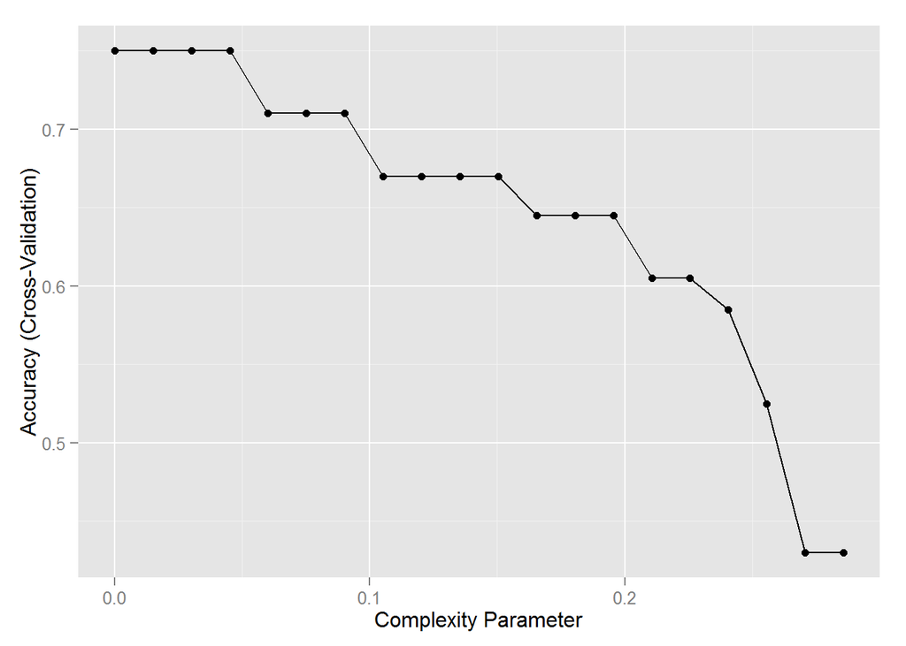

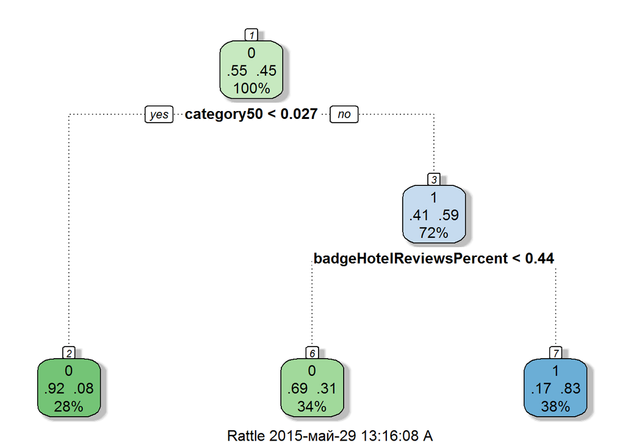

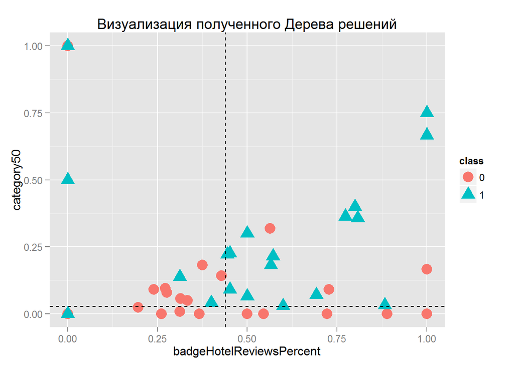

Видим, что с ростом объема обучающей выборки данный метод начинает давать более осмысленные результаты. Однако, точность предсказания слишком низкая.

### Случайный лес (Random Forest)

```
## Random Forest
##
## 47 samples
## 28 predictors
##  2 classes: '0', '1'
##
## No pre-processing
## Resampling: Cross-Validated (10 fold)
##
## Summary of sample sizes: 43, 42, 43, 41, 42, 42, ...
##
## Resampling results across tuning parameters:
##
##   mtry  Accuracy   Kappa      Accuracy SD  Kappa SD
##    2    0.5950000  0.1959374  0.1423025    0.2739390
##    3    0.6158333  0.2445971  0.1389681    0.2758249
##    5    0.6116667  0.2455711  0.1685175    0.3048944
##    9    0.6366667  0.2862637  0.1398412    0.2753013
##   18    0.6166667  0.2413919  0.1276569    0.2512116
##   26    0.5916667  0.1913919  0.1230402    0.2436659
##   38    0.5750000  0.1580586  0.1230402    0.2448877
##   51    0.6083333  0.2247253  0.1438556    0.2846021
##   76    0.5883333  0.1917582  0.1271846    0.2514893
##
## Accuracy was used to select the optimal model using  the largest value.
## The final value used for the model was mtry = 9.
```

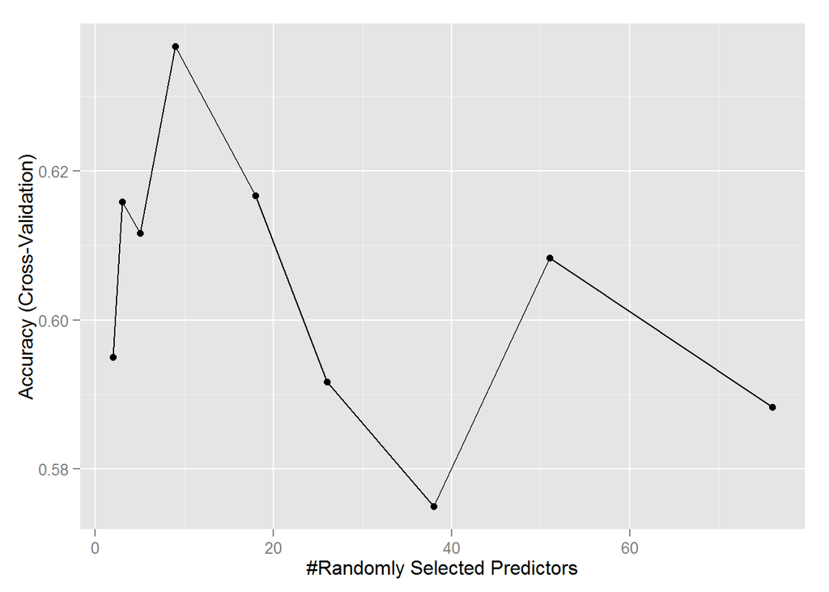

### Метод опорных векторов (Support Vector Machine)

Известно, что для задач классификации лучше подходит ядро на снове радиальной базисной функцииЮ нежели чем линейное ядро. Однако, тесты показывют, что лдинейное ядро работает лучше.

```
## Support Vector Machines with Linear Kernel
##
## 47 samples
## 28 predictors
##  2 classes: '0', '1'
##
## No pre-processing
## Resampling: Cross-Validated (10 fold)
##
## Summary of sample sizes: 43, 42, 43, 41, 42, 42, ...
##
## Resampling results across tuning parameters:
##
##   C      Accuracy   Kappa       Accuracy SD  Kappa SD
##    0.03  0.5150000  0.01470196  0.1732852    0.3692840
##    0.10  0.5066667  0.02509158  0.2302977    0.4452689
##    0.30  0.5266667  0.08076923  0.1293860    0.2356286
##    0.50  0.5433333  0.11410256  0.1571741    0.2921308
##    0.60  0.5433333  0.11410256  0.1571741    0.2921308
##    0.70  0.5433333  0.11410256  0.1571741    0.2921308
##    0.80  0.5433333  0.11410256  0.1571741    0.2921308
##    0.90  0.5433333  0.11410256  0.1571741    0.2921308
##    1.00  0.5433333  0.11410256  0.1571741    0.2921308
##    1.10  0.5433333  0.11410256  0.1571741    0.2921308
##    1.50  0.5883333  0.18076923  0.1583187    0.3071844
##    3.00  0.5883333  0.18076923  0.1583187    0.3071844
##   10.00  0.5883333  0.18076923  0.1583187    0.3071844
##   15.00  0.5883333  0.18076923  0.1583187    0.3071844
##
## Accuracy was used to select the optimal model using  the largest value.
## The final value used for the model was C = 1.5.
```

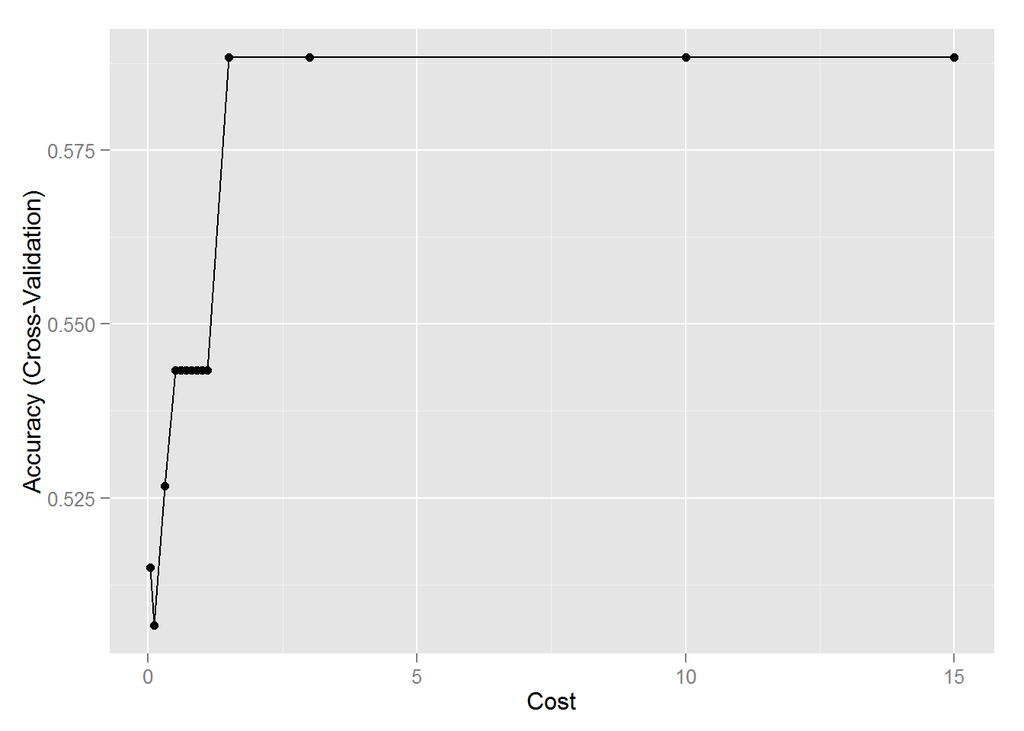

### Логистическая регрессия (Generalized Linear Model)

Всегда чуть хуже, чем Boostet GLM, поэтому не рассматриваем.

### Boosted Generalized Linear Model

```
## Boosted Generalized Linear Model
##
## 47 samples
## 28 predictors
##  2 classes: '0', '1'
##
## No pre-processing
## Resampling: Cross-Validated (10 fold)
##
## Summary of sample sizes: 43, 43, 41, 42, 43, 42, ...
##
## Resampling results across tuning parameters:
##
##   mstop  Accuracy   Kappa        Accuracy SD  Kappa SD
##     50   0.4500000  -0.13636364  0.2896358    0.6036568
##    100   0.4500000  -0.13636364  0.2368778    0.5032797
##    150   0.4533333  -0.11841492  0.2250926    0.4732487
##    200   0.4933333  -0.03508159  0.2101146    0.4380419
##    250   0.4933333  -0.03508159  0.2101146    0.4380419
##    300   0.4783333  -0.08181818  0.2042828    0.4269514
##    350   0.4783333  -0.08181818  0.2042828    0.4269514
##    400   0.5116667  -0.01515152  0.2051874    0.4352820
##    450   0.5283333   0.01818182  0.2249897    0.4758101
##    500   0.5283333   0.01818182  0.2249897    0.4758101
##    550   0.5116667  -0.01515152  0.2051874    0.4352820
##    600   0.5116667  -0.01515152  0.2051874    0.4352820
##    650   0.5116667  -0.01515152  0.2051874    0.4352820
##    700   0.4866667  -0.06515152  0.1873796    0.3965242
##    750   0.4866667  -0.06515152  0.1873796    0.3965242
##    800   0.4866667  -0.06515152  0.1873796    0.3965242
##    850   0.4866667  -0.06515152  0.1873796    0.3965242
##    900   0.4866667  -0.06515152  0.1873796    0.3965242
##    950   0.4866667  -0.06515152  0.1873796    0.3965242
##   1000   0.4866667  -0.06515152  0.1873796    0.3965242
##
## Tuning parameter 'prune' was held constant at a value of no
## Accuracy was used to select the optimal model using  the largest value.
## The final values used for the model were mstop = 450 and prune = no.
```

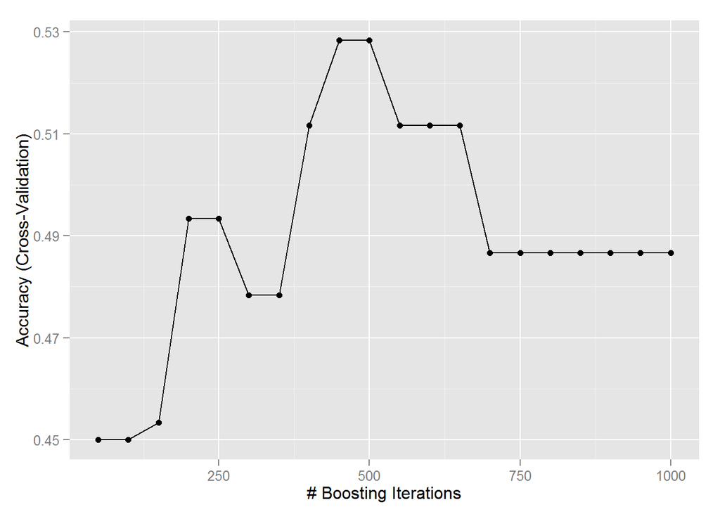

Несмотря на невысокую точность модели, проведем ее анализ с целью определить, какие параметры пользователя оказывали наибольшее влияние на результат.

```
## ROC curve variable importance
##
##   only 20 most important variables shown (out of 28)
##
##                           Importance
## category50                    100.00
## badgeHotelReviewsPercent       83.44
## ageGroup                       80.52
## userRating35                   65.26
## tagGourmet                     56.82
## tagNone                        56.17
## sex                            54.87
## tagLuxury                      53.25
## VIPBPYCount                    50.32
## tagJoinCulture                 46.75
## category30                     46.75
## publicationsCount              46.10
## category00                     44.81
## badgeFirstToReviewCount        43.18
## travelStatWorldPercent         40.26
## tagArts                        39.94
## badgeFirstToReviewPercent      39.61
## tagExtreme                     38.31
## tagHistory                     36.69
## reviews3Percent                34.74
```

### Generalized Linear Model with Stepwise Feature Selection

Работает очень медленно. За 20 минут нет результата при tuneLength=20.

### Нейросеть с 1 уровнем (pcaNNet)

```
##    user  system elapsed
##    2.35    0.17   56.13
```

```
## Neural Networks with Feature Extraction
##
## 47 samples
## 28 predictors
##  2 classes: '0', '1'
##
## No pre-processing
## Resampling: Cross-Validated (10 fold)
##
## Summary of sample sizes: 42, 42, 42, 43, 42, 42, ...
##
## Resampling results across tuning parameters:
##
##   decay  size  Accuracy  Kappa          Accuracy SD  Kappa SD
##   0.010   4    0.530     -0.0002331002  0.1719173    0.3560910
##   0.010   5    0.525     -0.0068764569  0.1513825    0.3054470
##   0.010   6    0.505     -0.0432400932  0.1535687    0.3255232
##   0.010   7    0.490     -0.0744755245  0.1468181    0.3245904
##   0.010   8    0.465     -0.1411421911  0.1155903    0.2419153
##   0.010  10    0.505     -0.0668997669  0.1535687    0.3016020
##   0.010  12    0.485     -0.0881118881  0.1203005    0.2458156
##   0.010  15    0.465     -0.1411421911  0.1155903    0.2419153
##   0.033   4    0.485     -0.0881118881  0.1203005    0.2458156
##   0.033   5    0.510     -0.0365967366  0.1744834    0.3741725
##   0.033   6    0.505     -0.0502331002  0.1535687    0.3101924
##   0.033   7    0.505     -0.0668997669  0.1535687    0.3016020
##   0.033   8    0.465     -0.1411421911  0.1155903    0.2419153
##   0.033  10    0.485     -0.1047785548  0.1203005    0.2318768
##   0.033  12    0.485     -0.0881118881  0.1203005    0.2458156
##   0.033  15    0.485     -0.0881118881  0.1203005    0.2458156
##   0.066   4    0.530      0.0067599068  0.1719173    0.3684695
##   0.066   5    0.485     -0.0796037296  0.1528434    0.3401387
##   0.066   6    0.465     -0.1411421911  0.1155903    0.2419153
##   0.066   7    0.470     -0.1441724942  0.1437591    0.3113617
##   0.066   8    0.485     -0.1047785548  0.1203005    0.2318768
##   0.066  10    0.485     -0.1047785548  0.1203005    0.2318768
##   0.066  12    0.445     -0.1775058275  0.1065885    0.2456435
##   0.066  15    0.485     -0.1047785548  0.1203005    0.2318768
##   0.100   4    0.485     -0.1047785548  0.1203005    0.2318768
##   0.100   5    0.485     -0.1047785548  0.1203005    0.2318768
##   0.100   6    0.505     -0.0668997669  0.1535687    0.3016020
##   0.100   7    0.485     -0.0881118881  0.1203005    0.2458156
##   0.100   8    0.465     -0.1411421911  0.1155903    0.2419153
##   0.100  10    0.510     -0.0547785548  0.1468181    0.3006807
##   0.100  12    0.485     -0.1047785548  0.1203005    0.2318768
##   0.100  15    0.465     -0.1411421911  0.1155903    0.2419153
##
## Accuracy was used to select the optimal model using  the largest value.
## The final values used for the model were size = 4 and decay = 0.066.
```

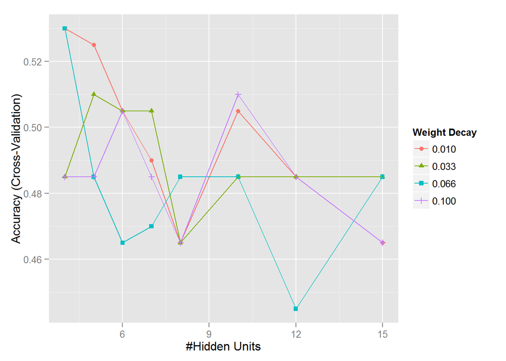

### Model Averaged Neural Network (nnet)

При данном подходе нейросеть обучается несколько раз для разных начальных значений счетчика случайных чисел. Предсказанные результаты усредняются. Following Ripley (1996), the same neural network model is fit using different random number seeds. All the resulting models are used for prediction. For regression, the output from each network are averaged. For classification, the model scores are first averaged, then translated to predicted classes. Bagging can also be used to create the models.

Всегда чуть хуже, чем предыдущая нейросеть. Рассчет отключен для экономии времени.

### Multi Layer Perceptron (RSNNS)

```
##    user  system elapsed
##    2.80    0.04   77.30
```

```
## Multi-Layer Perceptron
##
## 47 samples
## 28 predictors
##  2 classes: '0', '1'
##
## No pre-processing
## Resampling: Cross-Validated (10 fold)
##
## Summary of sample sizes: 42, 42, 42, 43, 42, 42, ...
##
## Resampling results across tuning parameters:
##
##   decay   size  Accuracy  Kappa  Accuracy SD  Kappa SD
##   0.0033   3    0.55      0      0.07071068   0
##   0.0033   4    0.55      0      0.07071068   0
##   0.0033   5    0.55      0      0.07071068   0
##   0.0033   6    0.55      0      0.07071068   0
##   0.0033   7    0.55      0      0.07071068   0
##   0.0033   8    0.55      0      0.07071068   0
##   0.0033  10    0.55      0      0.07071068   0
##   0.0100   3    0.55      0      0.07071068   0
##   0.0100   4    0.55      0      0.07071068   0
##   0.0100   5    0.53      0      0.08232726   0
##   0.0100   6    0.53      0      0.08232726   0
##   0.0100   7    0.55      0      0.07071068   0
##   0.0100   8    0.55      0      0.07071068   0
##   0.0100  10    0.53      0      0.08232726   0
##   0.0330   3    0.53      0      0.08232726   0
##   0.0330   4    0.49      0      0.08755950   0
##   0.0330   5    0.53      0      0.08232726   0
##   0.0330   6    0.53      0      0.08232726   0
##   0.0330   7    0.53      0      0.08232726   0
##   0.0330   8    0.53      0      0.08232726   0
##   0.0330  10    0.51      0      0.08755950   0
##   0.0660   3    0.53      0      0.08232726   0
##   0.0660   4    0.53      0      0.08232726   0
##   0.0660   5    0.53      0      0.08232726   0
##   0.0660   6    0.55      0      0.07071068   0
##   0.0660   7    0.49      0      0.08755950   0
##   0.0660   8    0.51      0      0.08755950   0
##   0.0660  10    0.55      0      0.07071068   0
##   0.1000   3    0.55      0      0.07071068   0
##   0.1000   4    0.57      0      0.04830459   0
##   0.1000   5    0.55      0      0.07071068   0
##   0.1000   6    0.53      0      0.08232726   0
##   0.1000   7    0.51      0      0.08755950   0
##   0.1000   8    0.55      0      0.07071068   0
##   0.1000  10    0.49      0      0.08755950   0
##
## Accuracy was used to select the optimal model using  the largest value.
## The final values used for the model were size = 4 and decay = 0.1.
```

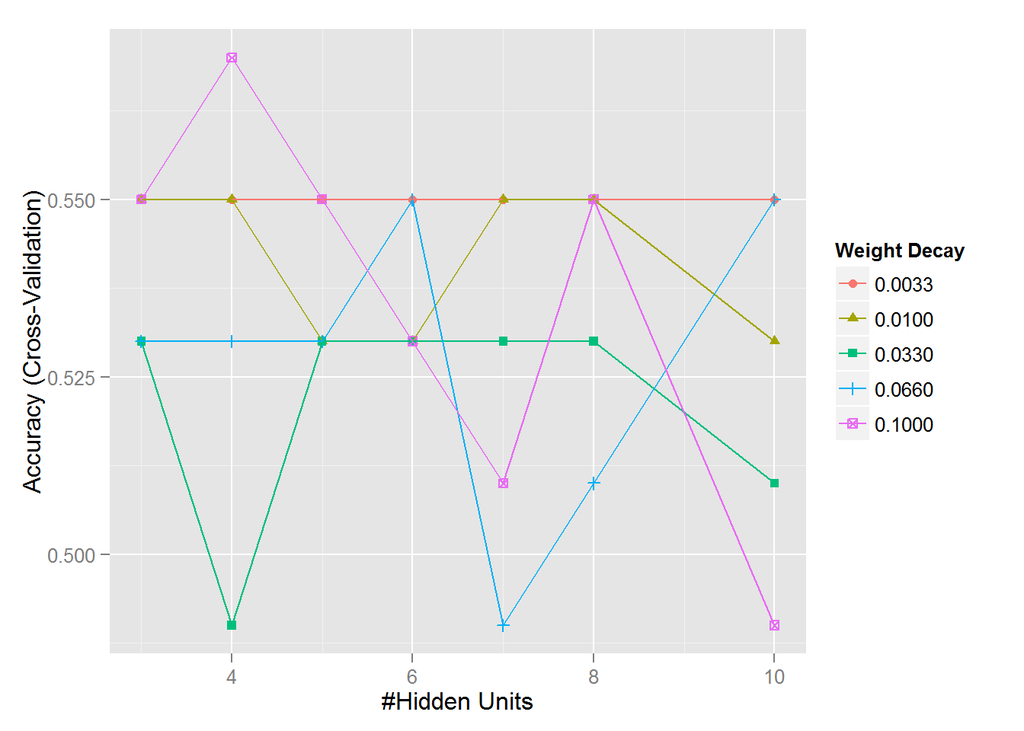

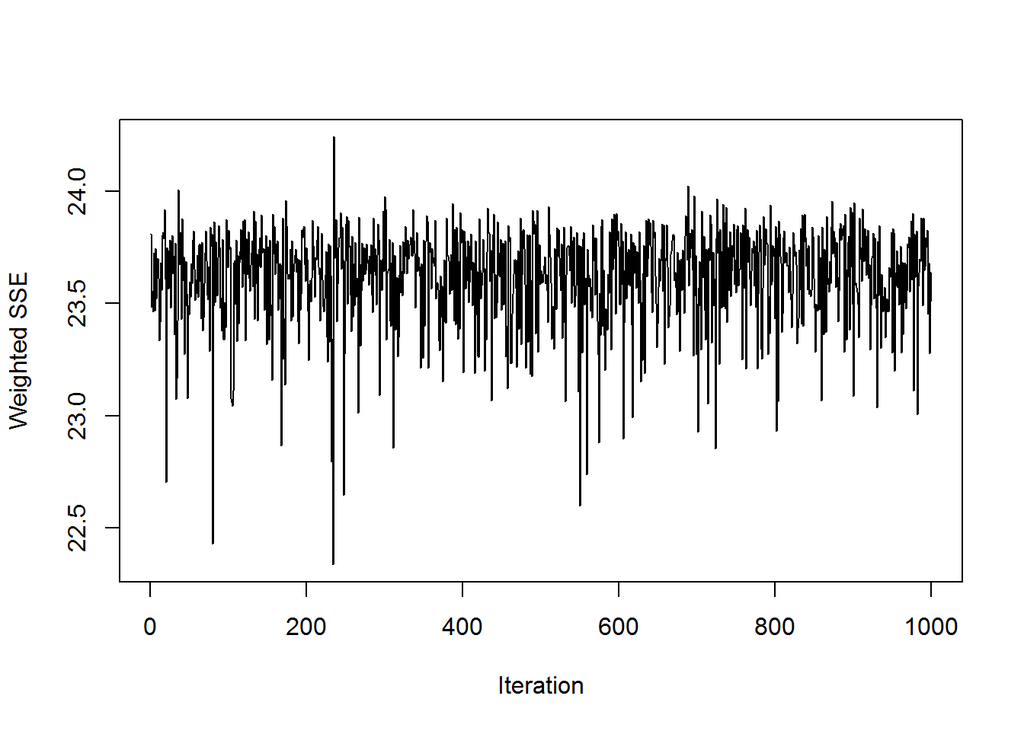

Последний график, кажется, говорит о том, что модель не дообучена.

### Stochastic Gradient Boosting, ~AdaBoost (gbm)

An implementation of extensions to Freund and Schapire’s AdaBoost algorithm and Friedman’s gradient boosting machine. Includes regression methods for least squares, absolute loss, t-distribution loss, quantile regression, logistic, multinomial logistic, Poisson, Cox proportional hazards partial likelihood, AdaBoost exponential loss, Huberized hinge loss, and Learning to Rank measures (LambdaMart). http://en.wikipedia.org/wiki/Gradient_boosting

Параметры модели:

- **n.minobsinnode** - minimum total weight needed in each node.It is used in the tree building process by ignoring any splits that lead to nodes containing fewer than this number of training set instances.
- **n.trees** - количество деревьев, которые будут построены.
- **interaction.depth** - the maximum depth of variable interactions. 1 implies an additive model, 2 implies a model with up to 2-way interactions, etc.

```
##    user  system elapsed
##    2.24    0.04   41.79
```

```
## A gradient boosted model with bernoulli loss function.
## 100 iterations were performed.
## There were 35 predictors of which 14 had non-zero influence.
```

```
## gbm variable importance
##
##   only 20 most important variables shown (out of 35)
##
##                           Overall
## badgeHotelReviewsPercent  100.000
## category50                 85.225
## travelStatWorldPercent     16.093
## userRating35               14.914
## tagNone                    14.725
## ageGroup.L                 14.302
## VIPBPYCount                10.863
## publicationsCount           8.062
## badgeFirstToReviewPercent   7.243
## category00                  6.655
## badgeFirstToReviewCount     6.328
## category30                  5.210
## ageGroup.Q                  4.658
## reviews3Percent             2.105
## category35                  0.000
## tagEconom                   0.000
## sexженщина                  0.000
## tagLuxury                   0.000
## tagGourmet                  0.000
## category25                  0.000
```

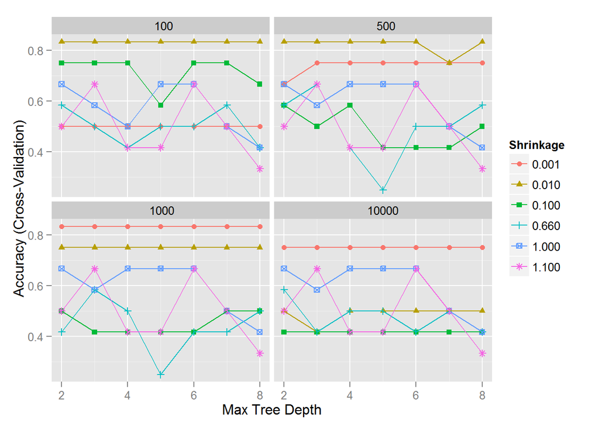

```
## gbm variable importance
##
##   only 20 most important variables shown (out of 35)
##
##                             Overall
## badgeHotelReviewsPercent    100.000
## category50                   85.225
## travelStatWorldPercent       16.093
## userRating35                 14.914
## tagNone                      14.725
## ageGroup.L                   14.302
## VIPBPYCount                  10.863
## publicationsCount             8.062
## badgeFirstToReviewPercent     7.243
## category00                    6.655
## badgeFirstToReviewCount       6.328
## category30                    5.210
## ageGroup.Q                    4.658
## reviews3Percent               2.105
## tagGourmet                    0.000
## ageGroup^4                    0.000
## badgeAttractionReviewsCount   0.000
## userRating00                  0.000
## tagLuxury                     0.000
## tagEconom                     0.000
```

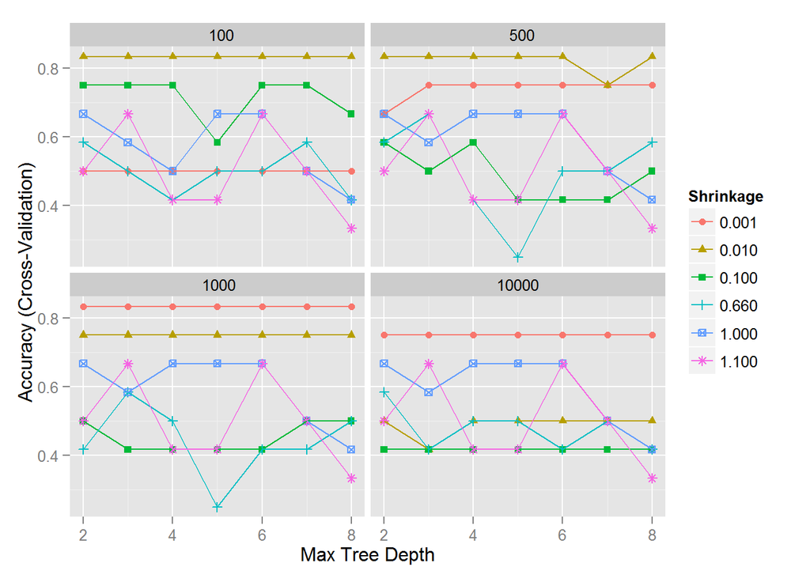

```
##    user  system elapsed
##    1.43    0.06    2.81
```

```
## A gradient boosted model with bernoulli loss function.
## 1000 iterations were performed.
## There were 35 predictors of which 16 had non-zero influence.
```

```
## gbm variable importance
##
##   only 20 most important variables shown (out of 35)
##
##                              Overall
## badgeHotelReviewsPercent    100.0000
## category50                   95.1756
## userRating35                 28.8394
## VIPBPYCount                  21.0932
## travelStatWorldPercent       16.2910
## ageGroup.L                   13.6885
## ageGroup.Q                    8.1361
## tagNone                       7.6921
## badgeFirstToReviewPercent     6.5504
## category00                    6.1543
## category30                    4.4880
## publicationsCount             3.5071
## badgeAttractionReviewsCount   2.0746
## reviews3Percent               1.7760
## badgeFirstToReviewCount       1.7282
## category45                    0.6747
## tagArts                       0.0000
## ageGroup^4                    0.0000
## tagHistory                    0.0000
## tagEconom                     0.0000
```

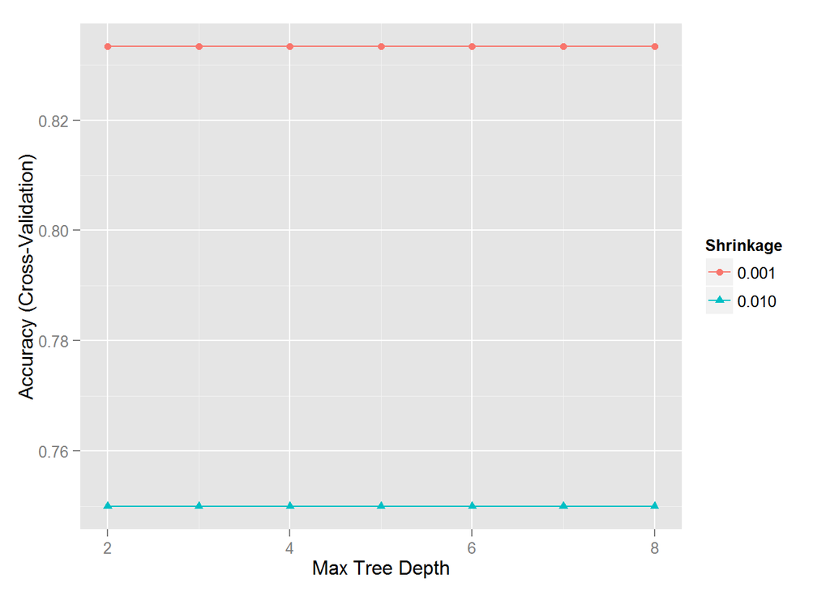

Видим, что вручную подобранная можелдь использует большее количество параметров пользователя.

### Анализ качества обученных моделей

[output not shown]

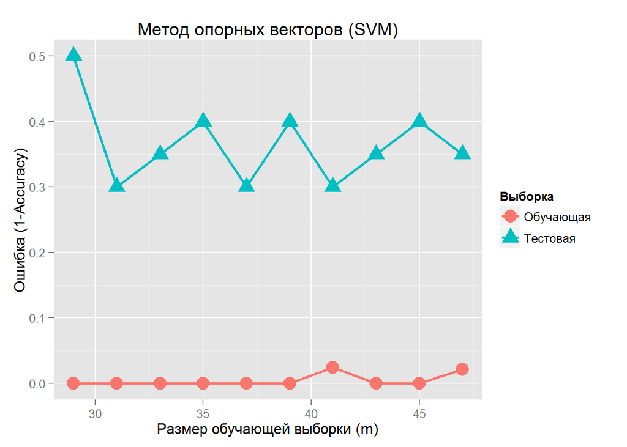

Из графика видим очень маленькую ошибку на обучающих данных и большую ошибку на тестовых данных. Из этого следует, что модель страдает от большого разброса (переобучена). Для улучшения модели следует сделать следующее:

- увеличить размер обучающей выборки, сейчас 47 экземпляров.
- сократить количество параметров, сейчас 29.

Проведем анализ сдвига/разброса на основе LogitBoost c параметром nIter =20.

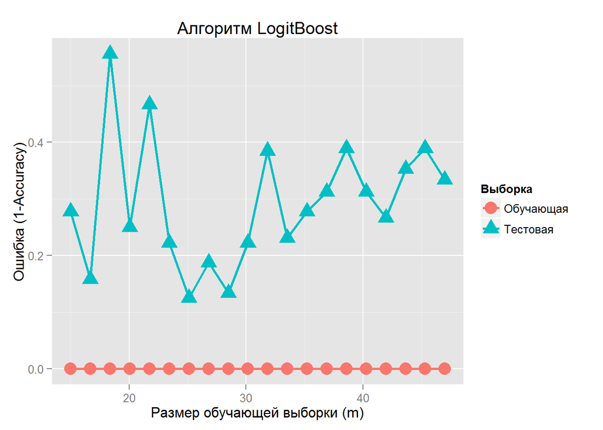

Выводы аналогичны выводам, сделанным для метода опорных векторов, модель переобучена (overfitted). Однако, здесь ошибка на тестовой выборке растет с увеличением размера обучающей выборки, т.е. эффект переобучения только увеличивается.

Проведем анализ сдвига/разброса на основе Случайного леса c параметром mtry =9.

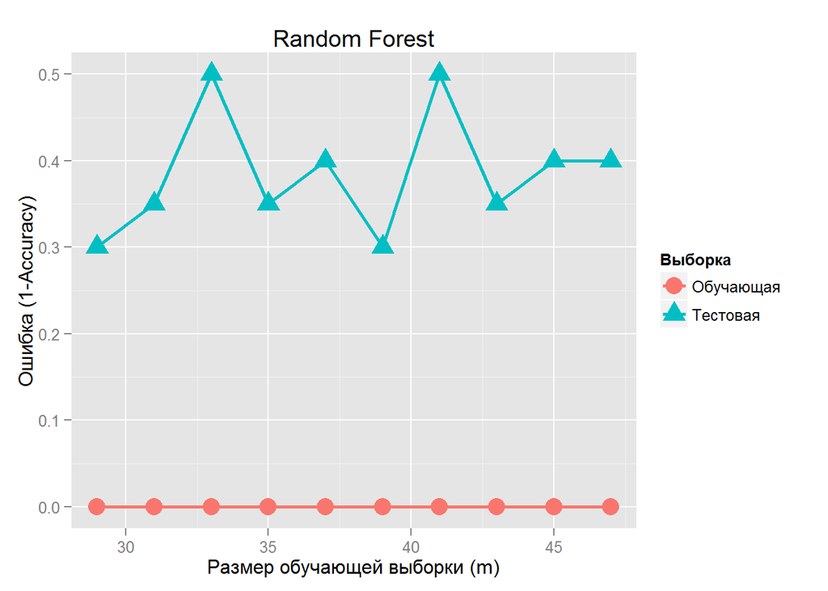

Проведем анализ сдвига/разброса на основе Дерева решений c параметром cp =0.0451128.

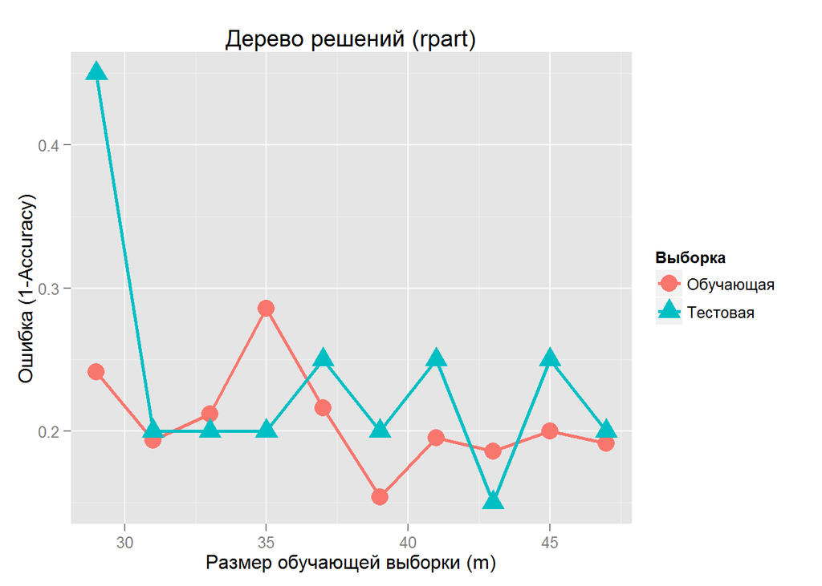

Этот график показывает, что, похоже, что модель не переобучена (графики сошлись), соответственно точность ~80%, которую мы видим на графике для обучающей и тестовой выборок при максимальных значениях размера выборки, является предельной для данной модели. Именно по этому признаку мы будем считать победившей модель “Дерево решений”.

Проведем анализ сдвига/разброса на основе Дерева решений c параметрами: n.trees = 1000, interaction.depth = 2, shrinkage = 0.001.

Выдается ошибка " final tuning parameters could not be determined" :(

### Метод опорных векторов (SVM) на сокращенной выборке

Попробуем искуственно решить проблему переобучения модели за счет сокращения количества параметров (features). Откажемся от использования сильно “разряженных” параметров “tag*“, параметров city, country, VIP*Count (т.к. есть аналогичные “Per Year” параметры).

(рассчет отключен)

Всегда получается худший результат. Это тупиковая ветвь, точнее, правильный выбор параметров надо делать через такие механизмы, как PCA, удаление высококоррелирующих и линейнозависимых параметров и т.п.

### Проверка лучшей модели на тестовой выборке

В качестве победившей по качеству предсказания на обучающих данных выбираем модель “Дерево решений (rpart)”. Оценим качество ее предсказания на тестовой выборке, которую модель на “видела” при обучении.

```
## Confusion Matrix and Statistics
##
##           Reference
## Prediction  0  1
##          0 10  3
##          1  1  6
##
##                Accuracy : 0.8
##                  95% CI : (0.5634, 0.9427)
##     No Information Rate : 0.55
##     P-Value [Acc > NIR] : 0.01886
##
##                   Kappa : 0.5876
##  Mcnemar's Test P-Value : 0.61708
##
##             Sensitivity : 0.9091
##             Specificity : 0.6667
##          Pos Pred Value : 0.7692
##          Neg Pred Value : 0.8571
##              Prevalence : 0.5500
##          Detection Rate : 0.5000
##    Detection Prevalence : 0.6500
##       Balanced Accuracy : 0.7879
##
##        'Positive' Class : 0
##
```

## Классификация новых пользователей (предсказание)

Делаем проверку всех представленных в этом файле моделей на исходных данных, в которых предстпавлена информациф обо всех посещенных отелях (вариант 3b). Получаем результаты хуже, чем без этих параметров.